# Shubham Kumar_KDAG

```python
import pandas as pd
import numpy as np
import matplotlib.pyplot as plt
%matplotlib inline
from sklearn.linear_model import LogisticRegression
from sklearn.svm import SVC
from sklearn.neighbors import KNeighborsClassifier
from sklearn.tree import DecisionTreeClassifier
```

```python
%pwd
```

```
'C:\\Users\\shubham kumar'
```

```python
train_dataset = pd.read_csv('train.csv')
test_dataset = pd.read_csv('test.csv')
```

INITIAL DESCRIPTION OF THE DATASET

```python
train_dataset.head()
```

|  | PassengerId | Survived | Pclass | Name | Sex | Age | SibSp | Parch | Ticket | Fare | Cabin | Embarked |
| --- | --- | --- | --- | --- | --- | --- | --- | --- | --- | --- | --- | --- |
| 0 | 1 | 0 | 3 | Braund, Mr. Owen Harris | male | 22.0 | 1 | 0 | A/5 21171 | 7.2500 | NaN | S |
| 1 | 2 | 1 | 1 | Cumings, Mrs. John Bradley (Florence Briggs Th... | female | 38.0 | 1 | 0 | PC 17599 | 71.2833 | C85 | C |
| 2 | 3 | 1 | 3 | Heikkinen, Miss. Laina | female | 26.0 | 0 | 0 | STON/O2. 3101282 | 7.9250 | NaN | S |
| 3 | 4 | 1 | 1 | Futrelle, Mrs. Jacques Heath (Lily May Peel) | female | 35.0 | 1 | 0 | 113803 | 53.1000 | C123 | S |
| 4 | 5 | 0 | 3 | Allen, Mr. William Henry | male | 35.0 | 0 | 0 | 373450 | 8.0500 | NaN | S |

```python
test_dataset.head()
```

|  | PassengerId | Pclass | Name | Sex | Age | SibSp | Parch | Ticket | Fare | Cabin | Embarked |
| --- | --- | --- | --- | --- | --- | --- | --- | --- | --- | --- | --- |
| 0 | 892 | 3 | Kelly, Mr. James | male | 34.5 | 0 | 0 | 330911 | 7.8292 | NaN | Q |
| 1 | 893 | 3 | Wilkes, Mrs. James (Ellen Needs) | female | 47.0 | 1 | 0 | 363272 | 7.0000 | NaN | S |
| 2 | 894 | 2 | Myles, Mr. Thomas Francis | male | 62.0 | 0 | 0 | 240276 | 9.6875 | NaN | Q |
| 3 | 895 | 3 | Wirz, Mr. Albert | male | 27.0 | 0 | 0 | 315154 | 8.6625 | NaN | S |
| 4 | 896 | 3 | Hirvonen, Mrs. Alexander (Helga E Lindqvist) | female | 22.0 | 1 | 1 | 3101298 | 12.2875 | NaN | S |

```python
train_dataset.shape
```

```
(891, 12)
```

```python
test_dataset.shape
```

```
(418, 11)
```

Missing column in test dataset is survived.So,we have to train our classifier using Train Dataset to predict about Survived in the test dataset.

```python
train_dataset.describe()
```

|  | PassengerId | Survived | Pclass | Age | SibSp | Parch | Fare |
| --- | --- | --- | --- | --- | --- | --- | --- |
| count | 891.000000 | 891.000000 | 891.000000 | 714.000000 | 891.000000 | 891.000000 | 891.000000 |
| mean | 446.000000 | 0.383838 | 2.308642 | 29.699118 | 0.523008 | 0.381594 | 32.204208 |
| std | 257.353842 | 0.486592 | 0.836071 | 14.526497 | 1.102743 | 0.806057 | 49.693429 |
| min | 1.000000 | 0.000000 | 1.000000 | 0.420000 | 0.000000 | 0.000000 | 0.000000 |
| 25% | 223.500000 | 0.000000 | 2.000000 | 20.125000 | 0.000000 | 0.000000 | 7.910400 |
| 50% | 446.000000 | 0.000000 | 3.000000 | 28.000000 | 0.000000 | 0.000000 | 14.454200 |
| 75% | 668.500000 | 1.000000 | 3.000000 | 38.000000 | 1.000000 | 0.000000 | 31.000000 |
| max | 891.000000 | 1.000000 | 3.000000 | 80.000000 | 8.000000 | 6.000000 | 512.329200 |

Here,we notice that survival rate(mean of survived) is equal to .3838.

```python
train_dataset.describe(include='all')
```

|  | PassengerId | Survived | Pclass | Name | Sex | Age | SibSp | Parch | Ticket | Fare | Cabin | Embarked |
| --- | --- | --- | --- | --- | --- | --- | --- | --- | --- | --- | --- | --- |
| count | 891.000000 | 891.000000 | 891.000000 | 891 | 891 | 714.000000 | 891.000000 | 891.000000 | 891 | 891.000000 | 204 | 889 |
| unique | NaN | NaN | NaN | 891 | 2 | NaN | NaN | NaN | 681 | NaN | 147 | 3 |
| top | NaN | NaN | NaN | Boulos, Mrs. Joseph (Sultana) | male | NaN | NaN | NaN | CA. 2343 | NaN | C23 C25 C27 | S |
| freq | NaN | NaN | NaN | 1 | 577 | NaN | NaN | NaN | 7 | NaN | 4 | 644 |
| mean | 446.000000 | 0.383838 | 2.308642 | NaN | NaN | 29.699118 | 0.523008 | 0.381594 | NaN | 32.204208 | NaN | NaN |
| std | 257.353842 | 0.486592 | 0.836071 | NaN | NaN | 14.526497 | 1.102743 | 0.806057 | NaN | 49.693429 | NaN | NaN |
| min | 1.000000 | 0.000000 | 1.000000 | NaN | NaN | 0.420000 | 0.000000 | 0.000000 | NaN | 0.000000 | NaN | NaN |
| 25% | 223.500000 | 0.000000 | 2.000000 | NaN | NaN | 20.125000 | 0.000000 | 0.000000 | NaN | 7.910400 | NaN | NaN |
| 50% | 446.000000 | 0.000000 | 3.000000 | NaN | NaN | 28.000000 | 0.000000 | 0.000000 | NaN | 14.454200 | NaN | NaN |
| 75% | 668.500000 | 1.000000 | 3.000000 | NaN | NaN | 38.000000 | 1.000000 | 0.000000 | NaN | 31.000000 | NaN | NaN |
| max | 891.000000 | 1.000000 | 3.000000 | NaN | NaN | 80.000000 | 8.000000 | 6.000000 | NaN | 512.329200 | NaN | NaN |

In the train dataset | Age Series we dont have the data for 891-714 = 177 fields. Also in cabin series we don't have data for 891-204 fields.

```python
train_dataset.info()
```

```
<class 'pandas.core.frame.DataFrame'>
RangeIndex: 891 entries, 0 to 890
Data columns (total 12 columns):
PassengerId    891 non-null int64
Survived       891 non-null int64
Pclass         891 non-null int64
Name           891 non-null object
Sex            891 non-null object
Age            714 non-null float64
SibSp          891 non-null int64
Parch          891 non-null int64
Ticket         891 non-null object
Fare           891 non-null float64
Cabin          204 non-null object
Embarked       889 non-null object
dtypes: float64(2), int64(5), object(5)
memory usage: 66.2+ KB
```

DATA VISUALISATION

Survived vs Not Survived

```python
train_dataset.Survived.value_counts()
```

```
0    549
1    342
Name: Survived, dtype: int64
```

out of 891: survived = 342 Not survived = 549

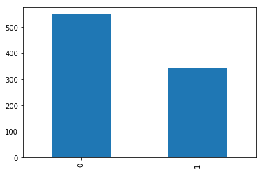

```python
train_dataset.Survived.value_counts().plot(kind='bar')
```

Pclass vs Survival

```python
train_dataset.Pclass.value_counts()
```

```
3    491
1    216
2    184
Name: Pclass, dtype: int64
```

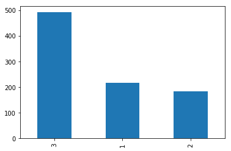

```python
train_dataset.Pclass.value_counts().plot(kind='bar')
```

```python
pd.crosstab(train_dataset.Pclass,train_dataset.Survived,normalize='index')
```

| Survived Pclass | 0 | 1 |
| --- | --- | --- |
| 1 | 0.370370 | 0.629630 |
| 2 | 0.527174 | 0.472826 |
| 3 | 0.757637 | 0.242363 |

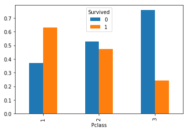

```python
pd.crosstab(train_dataset.Pclass,train_dataset.Survived,normalize= 'index').plot(kind='bar')
```

Higher class people have greater chances of survival.

sex vs survival

```python
pd.crosstab(train_dataset.Sex,train_dataset.Survived,normalize='index')
```

| Survived Sex | 0 | 1 |
| --- | --- | --- |
| female | 0.257962 | 0.742038 |
| male | 0.811092 | 0.188908 |

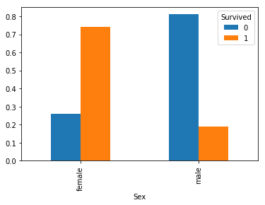

```python
pd.crosstab(train_dataset.Sex,train_dataset.Survived,normalize='index').plot(kind='bar')
```

Female have greater chances of survival.

Embarked vs Survived

```python
train_dataset.Embarked.value_counts()
```

```
S    644
C    168
Q     77
Name: Embarked, dtype: int64
```

```python
pd.crosstab(train_dataset.Embarked,train_dataset.Survived,normalize='index')
```

| Survived Embarked | 0 | 1 |
| --- | --- | --- |
| C | 0.446429 | 0.553571 |
| Q | 0.610390 | 0.389610 |
| S | 0.663043 | 0.336957 |

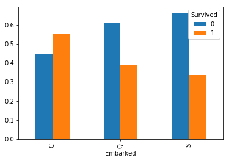

```python
pd.crosstab(train_dataset.Embarked,train_dataset.Survived,normalize='index').plot(kind='bar')
```

Parch vs Survived

```python
train_dataset.Parch.value_counts()
```

```
0    678
1    118
2     80
5      5
3      5
4      4
6      1
Name: Parch, dtype: int64
```

```python
pd.crosstab(train_dataset.Parch,train_dataset.Survived,normalize='index')
```

| Survived Parch | 0 | 1 |
| --- | --- | --- |
| 0 | 0.656342 | 0.343658 |
| 1 | 0.449153 | 0.550847 |
| 2 | 0.500000 | 0.500000 |
| 3 | 0.400000 | 0.600000 |
| 4 | 1.000000 | 0.000000 |
| 5 | 0.800000 | 0.200000 |
| 6 | 1.000000 | 0.000000 |

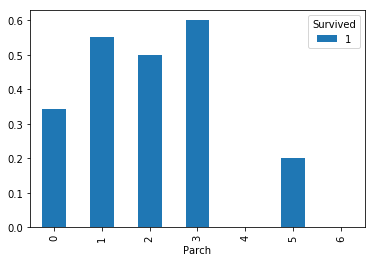

```python
pd.crosstab(train_dataset.Parch,train_dataset.Survived,normalize='index').drop(0,axis=1).plot(kind='bar')
```

SibSp vs Survived

```python
train_dataset.SibSp.value_counts()
```

```
0    608
1    209
2     28
4     18
3     16
8      7
5      5
Name: SibSp, dtype: int64
```

```python
pd.crosstab(train_dataset.SibSp,train_dataset.Survived,normalize=True)
```

| Survived SibSp | 0 | 1 |
| --- | --- | --- |
| 0 | 0.446689 | 0.235690 |
| 1 | 0.108866 | 0.125701 |
| 2 | 0.016835 | 0.014590 |
| 3 | 0.013468 | 0.004489 |
| 4 | 0.016835 | 0.003367 |
| 5 | 0.005612 | 0.000000 |
| 8 | 0.007856 | 0.000000 |

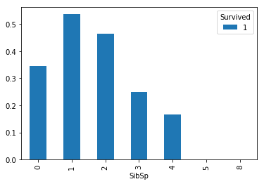

```python
pd.crosstab(train_dataset.SibSp,train_dataset.Survived,normalize='index').drop(0,axis=1).plot(kind='bar')
```

Age vs Survived

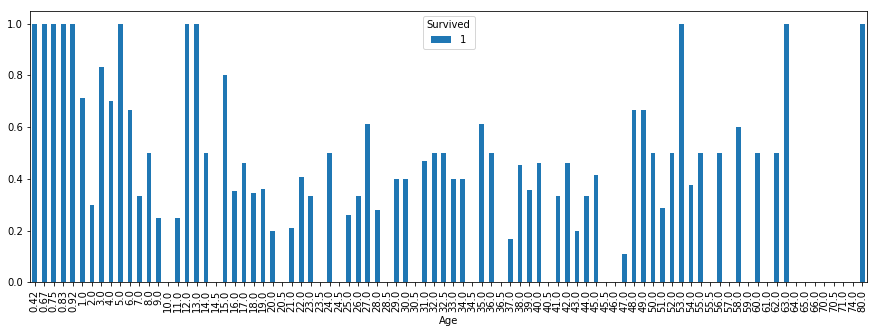

```python
pd.crosstab(train_dataset.Age,train_dataset.Survived,normalize='index').drop(0,axis=1).plot(kind='bar',figsize=(15,5))
```

```python
train_dataset.head()
```

|  | PassengerId | Survived | Pclass | Name | Sex | Age | SibSp | Parch | Ticket | Fare | Cabin | Embarked |
| --- | --- | --- | --- | --- | --- | --- | --- | --- | --- | --- | --- | --- |
| 0 | 1 | 0 | 3 | Braund, Mr. Owen Harris | male | 22.0 | 1 | 0 | A/5 21171 | 7.2500 | NaN | S |
| 1 | 2 | 1 | 1 | Cumings, Mrs. John Bradley (Florence Briggs Th... | female | 38.0 | 1 | 0 | PC 17599 | 71.2833 | C85 | C |
| 2 | 3 | 1 | 3 | Heikkinen, Miss. Laina | female | 26.0 | 0 | 0 | STON/O2. 3101282 | 7.9250 | NaN | S |
| 3 | 4 | 1 | 1 | Futrelle, Mrs. Jacques Heath (Lily May Peel) | female | 35.0 | 1 | 0 | 113803 | 53.1000 | C123 | S |
| 4 | 5 | 0 | 3 | Allen, Mr. William Henry | male | 35.0 | 0 | 0 | 373450 | 8.0500 | NaN | S |

FEATURE ENGINEERING

AGE

```python
train_dataset.Age.describe()
```

```
count    714.000000
mean      29.699118
std       14.526497
min        0.420000
25%       20.125000
50%       28.000000
75%       38.000000
max       80.000000
Name: Age, dtype: float64
```

Age column has some missing values.replacing them with median.

```python
train_dataset.Age.median()
```

```
28.0
```

```python
train_dataset.Age.fillna(value=(train_dataset.Age.median()),inplace=True)
```

divide the Ages into different agegroups namely 0-15,15-30,30-45,45-60 and 60-80.

```python
AgeGroup=[]
for i in train_dataset.Age:
    if ((i>=0) & (i<15)):
        x=0
    elif ((i>=15) & (i<30)):
        x=1
    elif ((i>=30) & (i<45)):
        x=2
    elif ((i>=45) & (i<60)):
        x=3
    else:
        x=4
    AgeGroup.append(x)
```

```python
train_dataset['AgeGroup']=AgeGroup
```

```python
train_dataset.head()
```

|  | PassengerId | Survived | Pclass | Name | Sex | Age | SibSp | Parch | Ticket | Fare | Cabin | Embarked | AgeGroup |
| --- | --- | --- | --- | --- | --- | --- | --- | --- | --- | --- | --- | --- | --- |
| 0 | 1 | 0 | 3 | Braund, Mr. Owen Harris | male | 22.0 | 1 | 0 | A/5 21171 | 7.2500 | NaN | S | 1 |
| 1 | 2 | 1 | 1 | Cumings, Mrs. John Bradley (Florence Briggs Th... | female | 38.0 | 1 | 0 | PC 17599 | 71.2833 | C85 | C | 2 |
| 2 | 3 | 1 | 3 | Heikkinen, Miss. Laina | female | 26.0 | 0 | 0 | STON/O2. 3101282 | 7.9250 | NaN | S | 1 |
| 3 | 4 | 1 | 1 | Futrelle, Mrs. Jacques Heath (Lily May Peel) | female | 35.0 | 1 | 0 | 113803 | 53.1000 | C123 | S | 2 |
| 4 | 5 | 0 | 3 | Allen, Mr. William Henry | male | 35.0 | 0 | 0 | 373450 | 8.0500 | NaN | S | 2 |

SEX

```python
train_dataset.Sex.replace({'male':1,'female':2},inplace=True)
```

```python
train_dataset.head()
```

|  | PassengerId | Survived | Pclass | Name | Sex | Age | SibSp | Parch | Ticket | Fare | Cabin | Embarked | AgeGroup |
| --- | --- | --- | --- | --- | --- | --- | --- | --- | --- | --- | --- | --- | --- |
| 0 | 1 | 0 | 3 | Braund, Mr. Owen Harris | 1 | 22.0 | 1 | 0 | A/5 21171 | 7.2500 | NaN | S | 1 |
| 1 | 2 | 1 | 1 | Cumings, Mrs. John Bradley (Florence Briggs Th... | 2 | 38.0 | 1 | 0 | PC 17599 | 71.2833 | C85 | C | 2 |
| 2 | 3 | 1 | 3 | Heikkinen, Miss. Laina | 2 | 26.0 | 0 | 0 | STON/O2. 3101282 | 7.9250 | NaN | S | 1 |
| 3 | 4 | 1 | 1 | Futrelle, Mrs. Jacques Heath (Lily May Peel) | 2 | 35.0 | 1 | 0 | 113803 | 53.1000 | C123 | S | 2 |
| 4 | 5 | 0 | 3 | Allen, Mr. William Henry | 1 | 35.0 | 0 | 0 | 373450 | 8.0500 | NaN | S | 2 |

Embarked

```python
train_dataset.Embarked.unique()
```

```
array(['S', 'C', 'Q', nan], dtype=object)
```

```python
train_dataset.Embarked.describe()
```

```
count     889
unique      3
top         S
freq      644
Name: Embarked, dtype: object
```

Embarked column has 2 missing values.

```python
train_dataset.Embarked.value_counts()
```

```
S    644
C    168
Q     77
Name: Embarked, dtype: int64
```

Since maximum Embarked value is 'S'.replace the missing values with 'S'.

```python
train_dataset.Embarked[train_dataset.Embarked.isnull()] ='S'
```

[output not shown]

```python
train_dataset.Embarked.unique()
```

```
array(['S', 'C', 'Q'], dtype=object)
```

```python
train_dataset.Embarked.replace({'C':0,'Q':1,'S':2},inplace=True)
```

```python
train_dataset.head()
```

|  | PassengerId | Survived | Pclass | Name | Sex | Age | SibSp | Parch | Ticket | Fare | Cabin | Embarked | AgeGroup |
| --- | --- | --- | --- | --- | --- | --- | --- | --- | --- | --- | --- | --- | --- |
| 0 | 1 | 0 | 3 | Braund, Mr. Owen Harris | 1 | 22.0 | 1 | 0 | A/5 21171 | 7.2500 | NaN | 2 | 1 |
| 1 | 2 | 1 | 1 | Cumings, Mrs. John Bradley (Florence Briggs Th... | 2 | 38.0 | 1 | 0 | PC 17599 | 71.2833 | C85 | 0 | 2 |
| 2 | 3 | 1 | 3 | Heikkinen, Miss. Laina | 2 | 26.0 | 0 | 0 | STON/O2. 3101282 | 7.9250 | NaN | 2 | 1 |
| 3 | 4 | 1 | 1 | Futrelle, Mrs. Jacques Heath (Lily May Peel) | 2 | 35.0 | 1 | 0 | 113803 | 53.1000 | C123 | 2 | 2 |
| 4 | 5 | 0 | 3 | Allen, Mr. William Henry | 1 | 35.0 | 0 | 0 | 373450 | 8.0500 | NaN | 2 | 2 |

Creating a new feature Alone from SibSp and Parch

```python
train_dataset['Alone']=((train_dataset.SibSp + train_dataset.Parch)==0).astype(int)
```

```python
train_dataset.head()
```

|  | PassengerId | Survived | Pclass | Name | Sex | Age | SibSp | Parch | Ticket | Fare | Cabin | Embarked | AgeGroup | Alone |
| --- | --- | --- | --- | --- | --- | --- | --- | --- | --- | --- | --- | --- | --- | --- |
| 0 | 1 | 0 | 3 | Braund, Mr. Owen Harris | 1 | 22.0 | 1 | 0 | A/5 21171 | 7.2500 | NaN | 2 | 1 | 0 |
| 1 | 2 | 1 | 1 | Cumings, Mrs. John Bradley (Florence Briggs Th... | 2 | 38.0 | 1 | 0 | PC 17599 | 71.2833 | C85 | 0 | 2 | 0 |
| 2 | 3 | 1 | 3 | Heikkinen, Miss. Laina | 2 | 26.0 | 0 | 0 | STON/O2. 3101282 | 7.9250 | NaN | 2 | 1 | 1 |
| 3 | 4 | 1 | 1 | Futrelle, Mrs. Jacques Heath (Lily May Peel) | 2 | 35.0 | 1 | 0 | 113803 | 53.1000 | C123 | 2 | 2 | 0 |
| 4 | 5 | 0 | 3 | Allen, Mr. William Henry | 1 | 35.0 | 0 | 0 | 373450 | 8.0500 | NaN | 2 | 2 | 1 |

FareDivide the fare into faregroups namely 1-8,8-15,15-30 and >30.

```python
FareGroup=[]
for i in train_dataset.Fare:
    if ((i>=0) & (i<8)):
        x=0
    elif ((i>=8) & (i<15)):
        x=1
    elif ((i>=15) & (i<30)):
        x=2
    else:
        x=4
    FareGroup.append(x)
```

```python
train_dataset['FareGroup']=FareGroup
```

```python
train_dataset.head()
```

|  | PassengerId | Survived | Pclass | Name | Sex | Age | SibSp | Parch | Ticket | Fare | Cabin | Embarked | AgeGroup | Alone | FareGroup |
| --- | --- | --- | --- | --- | --- | --- | --- | --- | --- | --- | --- | --- | --- | --- | --- |
| 0 | 1 | 0 | 3 | Braund, Mr. Owen Harris | 1 | 22.0 | 1 | 0 | A/5 21171 | 7.2500 | NaN | 2 | 1 | 0 | 0 |
| 1 | 2 | 1 | 1 | Cumings, Mrs. John Bradley (Florence Briggs Th... | 2 | 38.0 | 1 | 0 | PC 17599 | 71.2833 | C85 | 0 | 2 | 0 | 4 |
| 2 | 3 | 1 | 3 | Heikkinen, Miss. Laina | 2 | 26.0 | 0 | 0 | STON/O2. 3101282 | 7.9250 | NaN | 2 | 1 | 1 | 0 |
| 3 | 4 | 1 | 1 | Futrelle, Mrs. Jacques Heath (Lily May Peel) | 2 | 35.0 | 1 | 0 | 113803 | 53.1000 | C123 | 2 | 2 | 0 | 4 |
| 4 | 5 | 0 | 3 | Allen, Mr. William Henry | 1 | 35.0 | 0 | 0 | 373450 | 8.0500 | NaN | 2 | 2 | 1 | 1 |

```python
train_dataset.FareGroup.value_counts()
```

```
0    241
4    240
1    216
2    194
Name: FareGroup, dtype: int64
```

Population of different faregroup.

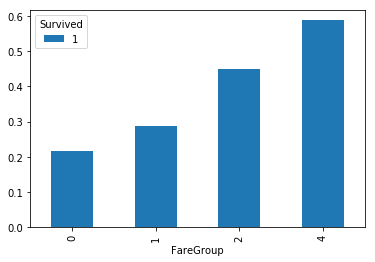

```python
pd.crosstab(train_dataset.FareGroup,train_dataset.Survived,normalize='index').drop(0,axis=1).plot(kind='bar')
```

people of higher faregroup have greater chances of survival.Nameseparating the title from ecach name and creating a new feature 'Title'.

```python
Title=[]
for i in train_dataset.Name:
    if i.find('Mr.') != -1:
        Title.append('Mr')
    elif i.find('Mrs.') != -1:
        Title.append('mrs')
    elif i.find('Miss.') != -1:
        Title.append('miss')
    else:
        Title.append('other')
```

```python
train_dataset['Title'] = Title
```

```python
train_dataset.head()
```

|  | PassengerId | Survived | Pclass | Name | Sex | Age | SibSp | Parch | Ticket | Fare | Cabin | Embarked | AgeGroup | Alone | FareGroup | Title |
| --- | --- | --- | --- | --- | --- | --- | --- | --- | --- | --- | --- | --- | --- | --- | --- | --- |
| 0 | 1 | 0 | 3 | Braund, Mr. Owen Harris | 1 | 22.0 | 1 | 0 | A/5 21171 | 7.2500 | NaN | 2 | 1 | 0 | 0 | Mr |
| 1 | 2 | 1 | 1 | Cumings, Mrs. John Bradley (Florence Briggs Th... | 2 | 38.0 | 1 | 0 | PC 17599 | 71.2833 | C85 | 0 | 2 | 0 | 4 | mrs |
| 2 | 3 | 1 | 3 | Heikkinen, Miss. Laina | 2 | 26.0 | 0 | 0 | STON/O2. 3101282 | 7.9250 | NaN | 2 | 1 | 1 | 0 | miss |
| 3 | 4 | 1 | 1 | Futrelle, Mrs. Jacques Heath (Lily May Peel) | 2 | 35.0 | 1 | 0 | 113803 | 53.1000 | C123 | 2 | 2 | 0 | 4 | mrs |
| 4 | 5 | 0 | 3 | Allen, Mr. William Henry | 1 | 35.0 | 0 | 0 | 373450 | 8.0500 | NaN | 2 | 2 | 1 | 1 | Mr |

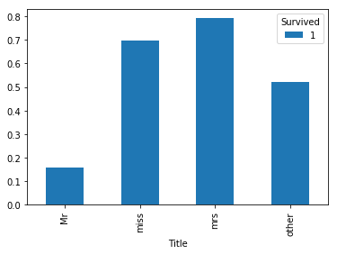

```python
pd.crosstab(train_dataset.Title,train_dataset.Survived,normalize='index').drop(0,axis=1).plot(kind='bar')
```

People with Mrs. or Miss title had greater chances of survival.

```python
train_dataset.Title.replace({'Mr':1,'mrs':2,'miss':3,'other':4},inplace=True)
```

```python
train_dataset.head()
```

|  | PassengerId | Survived | Pclass | Name | Sex | Age | SibSp | Parch | Ticket | Fare | Cabin | Embarked | AgeGroup | Alone | FareGroup | Title |
| --- | --- | --- | --- | --- | --- | --- | --- | --- | --- | --- | --- | --- | --- | --- | --- | --- |
| 0 | 1 | 0 | 3 | Braund, Mr. Owen Harris | 1 | 22.0 | 1 | 0 | A/5 21171 | 7.2500 | NaN | 2 | 1 | 0 | 0 | 1 |
| 1 | 2 | 1 | 1 | Cumings, Mrs. John Bradley (Florence Briggs Th... | 2 | 38.0 | 1 | 0 | PC 17599 | 71.2833 | C85 | 0 | 2 | 0 | 4 | 2 |
| 2 | 3 | 1 | 3 | Heikkinen, Miss. Laina | 2 | 26.0 | 0 | 0 | STON/O2. 3101282 | 7.9250 | NaN | 2 | 1 | 1 | 0 | 3 |
| 3 | 4 | 1 | 1 | Futrelle, Mrs. Jacques Heath (Lily May Peel) | 2 | 35.0 | 1 | 0 | 113803 | 53.1000 | C123 | 2 | 2 | 0 | 4 | 2 |
| 4 | 5 | 0 | 3 | Allen, Mr. William Henry | 1 | 35.0 | 0 | 0 | 373450 | 8.0500 | NaN | 2 | 2 | 1 | 1 | 1 |

Removing unnecessary features from the train dataframe.

```python
train_dataset.drop(['PassengerId','Name','Age','SibSp','Parch','Ticket','Fare','Cabin'],axis=1,inplace=True)
```

```python
train_dataset.head()
```

|  | Survived | Pclass | Sex | Embarked | AgeGroup | Alone | FareGroup | Title |
| --- | --- | --- | --- | --- | --- | --- | --- | --- |
| 0 | 0 | 3 | 1 | 2 | 1 | 0 | 0 | 1 |
| 1 | 1 | 1 | 2 | 0 | 2 | 0 | 4 | 2 |
| 2 | 1 | 3 | 2 | 2 | 1 | 1 | 0 | 3 |
| 3 | 1 | 1 | 2 | 2 | 2 | 0 | 4 | 2 |
| 4 | 0 | 3 | 1 | 2 | 2 | 1 | 1 | 1 |

Preparing test dataset

```python
test_dataset.head()
```

|  | PassengerId | Pclass | Name | Sex | Age | SibSp | Parch | Ticket | Fare | Cabin | Embarked |
| --- | --- | --- | --- | --- | --- | --- | --- | --- | --- | --- | --- |
| 0 | 892 | 3 | Kelly, Mr. James | male | 34.5 | 0 | 0 | 330911 | 7.8292 | NaN | Q |
| 1 | 893 | 3 | Wilkes, Mrs. James (Ellen Needs) | female | 47.0 | 1 | 0 | 363272 | 7.0000 | NaN | S |
| 2 | 894 | 2 | Myles, Mr. Thomas Francis | male | 62.0 | 0 | 0 | 240276 | 9.6875 | NaN | Q |
| 3 | 895 | 3 | Wirz, Mr. Albert | male | 27.0 | 0 | 0 | 315154 | 8.6625 | NaN | S |
| 4 | 896 | 3 | Hirvonen, Mrs. Alexander (Helga E Lindqvist) | female | 22.0 | 1 | 1 | 3101298 | 12.2875 | NaN | S |

```python
title=[]
for i in test_dataset.Name:
    if i.find('Mr.') != -1:
        title.append('Mr')
    elif i.find('Mrs.') != -1:
        title.append('mrs')
    elif i.find('Miss.') != -1:
        title.append('miss')
    else:
        title.append('other')
```

```python
test_dataset['Title'] = title
```

```python
test_dataset.Age.fillna(value=(test_dataset.Age.median()),inplace=True)
ageGroup=[]
for i in test_dataset.Age:
    if ((i>=0) & (i<15)):
        x=0
    elif ((i>=15) & (i<30)):
        x=1
    elif ((i>=30) & (i<45)):
        x=2
    elif ((i>=45) & (i<60)):
        x=3
    else:
        x=4
    ageGroup.append(x)
```

```python
test_dataset['AgeGroup'] = ageGroup
```

```python
test_dataset.head()
```

|  | PassengerId | Pclass | Name | Sex | Age | SibSp | Parch | Ticket | Fare | Cabin | Embarked | Title | AgeGroup |
| --- | --- | --- | --- | --- | --- | --- | --- | --- | --- | --- | --- | --- | --- |
| 0 | 892 | 3 | Kelly, Mr. James | male | 34.5 | 0 | 0 | 330911 | 7.8292 | NaN | Q | Mr | 2 |
| 1 | 893 | 3 | Wilkes, Mrs. James (Ellen Needs) | female | 47.0 | 1 | 0 | 363272 | 7.0000 | NaN | S | mrs | 3 |
| 2 | 894 | 2 | Myles, Mr. Thomas Francis | male | 62.0 | 0 | 0 | 240276 | 9.6875 | NaN | Q | Mr | 4 |
| 3 | 895 | 3 | Wirz, Mr. Albert | male | 27.0 | 0 | 0 | 315154 | 8.6625 | NaN | S | Mr | 1 |
| 4 | 896 | 3 | Hirvonen, Mrs. Alexander (Helga E Lindqvist) | female | 22.0 | 1 | 1 | 3101298 | 12.2875 | NaN | S | mrs | 1 |

```python
test_dataset['Alone']=((test_dataset.SibSp + test_dataset.Parch)==0).astype(int)
```

```python
fareGroup=[]
for i in test_dataset.Fare:
    if ((i>=0) & (i<8)):
        x=0
    elif ((i>=8) & (i<15)):
        x=1
    elif ((i>=15) & (i<30)):
        x=2
    else:
        x=4
    fareGroup.append(x)
```

```python
test_dataset['FareGroup'] = fareGroup
```

```python
test_dataset.Embarked.unique()
```

```
array(['Q', 'S', 'C'], dtype=object)
```

```python
test_dataset.Embarked.replace({'C':0,'Q':1,'S':2},inplace=True)
```

```python
test_dataset.Title.replace({'Mr':1,'mrs':2,'miss':3,'other':4},inplace=True)
```

```python
test_dataset.Sex.replace({'male':1,'female':2},inplace=True)
```

```python
test_dataset.head()
```

|  | PassengerId | Pclass | Name | Sex | Age | SibSp | Parch | Ticket | Fare | Cabin | Embarked | Title | AgeGroup | Alone | FareGroup |
| --- | --- | --- | --- | --- | --- | --- | --- | --- | --- | --- | --- | --- | --- | --- | --- |
| 0 | 892 | 3 | Kelly, Mr. James | 1 | 34.5 | 0 | 0 | 330911 | 7.8292 | NaN | 1 | 1 | 2 | 1 | 0 |
| 1 | 893 | 3 | Wilkes, Mrs. James (Ellen Needs) | 2 | 47.0 | 1 | 0 | 363272 | 7.0000 | NaN | 2 | 2 | 3 | 0 | 0 |
| 2 | 894 | 2 | Myles, Mr. Thomas Francis | 1 | 62.0 | 0 | 0 | 240276 | 9.6875 | NaN | 1 | 1 | 4 | 1 | 1 |
| 3 | 895 | 3 | Wirz, Mr. Albert | 1 | 27.0 | 0 | 0 | 315154 | 8.6625 | NaN | 2 | 1 | 1 | 1 | 1 |
| 4 | 896 | 3 | Hirvonen, Mrs. Alexander (Helga E Lindqvist) | 2 | 22.0 | 1 | 1 | 3101298 | 12.2875 | NaN | 2 | 2 | 1 | 0 | 1 |

```python
test_dataset.drop(['Name','Age','SibSp','Parch','Ticket','Fare','Cabin'],axis=1,inplace=True)
```

```python
test_dataset.head()
```

|  | PassengerId | Pclass | Sex | Embarked | Title | AgeGroup | Alone | FareGroup |
| --- | --- | --- | --- | --- | --- | --- | --- | --- |
| 0 | 892 | 3 | 1 | 1 | 1 | 2 | 1 | 0 |
| 1 | 893 | 3 | 2 | 2 | 2 | 3 | 0 | 0 |
| 2 | 894 | 2 | 1 | 1 | 1 | 4 | 1 | 1 |
| 3 | 895 | 3 | 1 | 2 | 1 | 1 | 1 | 1 |
| 4 | 896 | 3 | 2 | 2 | 2 | 1 | 0 | 1 |

PREDICTION AND ACCURACY

```python
X_test = test_dataset.drop('PassengerId',axis=1)
```

```python
X_train = train_dataset.drop('Survived',axis=1)
```

```python
Y_train = train_dataset.Survived
```

Logistic Regresion

```python
model = LogisticRegression()
```

```python
model.fit(X_train,Y_train)
```

```
LogisticRegression(C=1.0, class_weight=None, dual=False, fit_intercept=True,
          intercept_scaling=1, max_iter=100, multi_class='ovr', n_jobs=1,
          penalty='l2', random_state=None, solver='liblinear', tol=0.0001,
          verbose=0, warm_start=False)
```

```python
Y_pred_log = model.predict(X_test)
```

```python
acc_log = round(model.score(X_train, Y_train) * 100, 2)
acc_log
```

```
79.909999999999997
```

Support Vector Machine

```python
svc = SVC()
```

```python
svc.fit(X_train, Y_train)
```

```
SVC(C=1.0, cache_size=200, class_weight=None, coef0=0.0,
  decision_function_shape='ovr', degree=3, gamma='auto', kernel='rbf',
  max_iter=-1, probability=False, random_state=None, shrinking=True,
  tol=0.001, verbose=False)
```

```python
Y_pred_svc = svc.predict(X_test)
```

```python
acc_svc = round(svc.score(X_train, Y_train) * 100, 2)
```

```python
acc_svc
```

```
83.049999999999997
```

Decision Tree

```python
decision_tree = DecisionTreeClassifier()
```

```python
decision_tree.fit(X_train, Y_train)
```

```
DecisionTreeClassifier(class_weight=None, criterion='gini', max_depth=None,
            max_features=None, max_leaf_nodes=None,
            min_impurity_decrease=0.0, min_impurity_split=None,
            min_samples_leaf=1, min_samples_split=2,
            min_weight_fraction_leaf=0.0, presort=False, random_state=None,
            splitter='best')
```

```python
Y_pred_decision_tree = decision_tree.predict(X_test)
```

```python
acc_decision_tree = round(decision_tree.score(X_train, Y_train) * 100, 2)
```

```python
acc_decision_tree
```

```
87.540000000000006
```

KNN

```python
knn = KNeighborsClassifier(n_neighbors = 3)
```

```python
knn.fit(X_train, Y_train)
```

```
KNeighborsClassifier(algorithm='auto', leaf_size=30, metric='minkowski',
           metric_params=None, n_jobs=1, n_neighbors=3, p=2,
           weights='uniform')
```

```python
y_pred_knn = knn.predict(X_test)
```

```python
acc_knn = round(knn.score(X_train, Y_train) * 100, 2)
acc_knn
```

```
85.75
```

Since,Decision Tree gives highest accuracy

```python
predicted_result = pd.DataFrame({'PassengerId': test_dataset["PassengerId"],"Survived": Y_pred_decision_tree})
```

```python
predicted_result
```

|  | PassengerId | Survived |
| --- | --- | --- |
| 0 | 892 | 0 |
| 1 | 893 | 0 |
| 2 | 894 | 0 |
| 3 | 895 | 0 |
| 4 | 896 | 0 |
| 5 | 897 | 0 |
| 6 | 898 | 0 |
| 7 | 899 | 0 |
| 8 | 900 | 0 |
| 9 | 901 | 1 |
| 10 | 902 | 0 |
| 11 | 903 | 0 |
| 12 | 904 | 1 |
| 13 | 905 | 0 |
| 14 | 906 | 1 |
| 15 | 907 | 1 |
| 16 | 908 | 0 |
| 17 | 909 | 0 |
| 18 | 910 | 0 |
| 19 | 911 | 0 |
| 20 | 912 | 0 |
| 21 | 913 | 0 |
| 22 | 914 | 1 |
| 23 | 915 | 0 |
| 24 | 916 | 1 |
| 25 | 917 | 0 |
| 26 | 918 | 0 |
| 27 | 919 | 0 |
| 28 | 920 | 0 |
| 29 | 921 | 1 |
| ... | ... | ... |
| 388 | 1280 | 0 |
| 389 | 1281 | 1 |
| 390 | 1282 | 0 |
| 391 | 1283 | 1 |
| 392 | 1284 | 1 |
| 393 | 1285 | 0 |
| 394 | 1286 | 1 |
| 395 | 1287 | 1 |
| 396 | 1288 | 0 |
| 397 | 1289 | 1 |
| 398 | 1290 | 0 |
| 399 | 1291 | 0 |
| 400 | 1292 | 1 |
| 401 | 1293 | 0 |
| 402 | 1294 | 0 |
| 403 | 1295 | 0 |
| 404 | 1296 | 0 |
| 405 | 1297 | 1 |
| 406 | 1298 | 0 |
| 407 | 1299 | 0 |
| 408 | 1300 | 0 |
| 409 | 1301 | 0 |
| 410 | 1302 | 0 |
| 411 | 1303 | 1 |
| 412 | 1304 | 0 |
| 413 | 1305 | 0 |
| 414 | 1306 | 0 |
| 415 | 1307 | 0 |
| 416 | 1308 | 0 |
| 417 | 1309 | 0 |